# Lecuture 4: 1-27-21 and 2-3-21 - Class Notes

## Generating a sequence of numbers

```r
# seq(from=1, to=1, by=((to-from) / (length.out-1)), length.out=NULL, along.with=NUL)
```

| argument | value |
| --- | --- |
| `from` | 1 |
| `to` | 1 |
| `by` | `(to-from) / (length.out-1)` |

```r
x = c(1,4,3)
x
```

```
[1] 1 4 3
```

```r
x = c("blue", "red", 'green')
x
```

```
[1] "blue"  "red"   "green"
```

```r
x[1]
```

```
[1] "blue"
```

```r
x = c(1,2,3,4,5,6,7,8,9,10)
x[1]
```

```
[1] 1
```

```r
median(x)
```

```
[1] 5.5
```

## manipulating matries or vectors

```r
help(matrix)
# outputs documentation in side window
```

```r
x = c(1,2,3,4,5,6,7,8,9,10)
y = c(10,9,8,7,6,5,4,3,2,1)
x+y
```

```
 [1] 11 11 11 11 11 11 11 11 11 11
```

## Installing Packages

```r
install.packages("tidyverse")
```

```r
library(tidyverse)
```

- the packages are typically “tidy data” meaning they are already in a data from, wont have to clean it up

```r
help(read.table)
```

## Importing Data

### Tidying Data

```r
help(read.table)
```

will be working with the `mpg` data frame today that contains 234 observations (rows) on 11 features (columns) for 38 models of cars:

```r
mpg
```

| manufacturer | model | displ | year | cyl | trans | drv | cty | hwy | fl | class |
| --- | --- | --- | --- | --- | --- | --- | --- | --- | --- | --- |
| audi | a4 | 1.8 | 1999 | 4 | auto(l5) | f | 18 | 29 | p | compact |
| audi | a4 | 1.8 | 1999 | 4 | manual(m5) | f | 21 | 29 | p | compact |
| audi | a4 | 2.0 | 2008 | 4 | manual(m6) | f | 20 | 31 | p | compact |
| audi | a4 | 2.0 | 2008 | 4 | auto(av) | f | 21 | 30 | p | compact |
| audi | a4 | 2.8 | 1999 | 6 | auto(l5) | f | 16 | 26 | p | compact |
| audi | a4 | 2.8 | 1999 | 6 | manual(m5) | f | 18 | 26 | p | compact |
| audi | a4 | 3.1 | 2008 | 6 | auto(av) | f | 18 | 27 | p | compact |
| audi | a4 quattro | 1.8 | 1999 | 4 | manual(m5) | 4 | 18 | 26 | p | compact |
| audi | a4 quattro | 1.8 | 1999 | 4 | auto(l5) | 4 | 16 | 25 | p | compact |
| audi | a4 quattro | 2.0 | 2008 | 4 | manual(m6) | 4 | 20 | 28 | p | compact |

[output cut: 224 more lines]

to get description of the features in `mpg`, use the help function:

```r
help(mpg)
```

to get numerical summaries of the features in `mpg`, use the `summary()` function:

```r
summary(mpg)
```

```
 manufacturer          model               displ            year
 Length:234         Length:234         Min.   :1.600   Min.   :1999
 Class :character   Class :character   1st Qu.:2.400   1st Qu.:1999
 Mode  :character   Mode  :character   Median :3.300   Median :2004
                                       Mean   :3.472   Mean   :2004
                                       3rd Qu.:4.600   3rd Qu.:2008
                                       Max.   :7.000   Max.   :2008
      cyl           trans               drv                 cty
 Min.   :4.000   Length:234         Length:234         Min.   : 9.00
 1st Qu.:4.000   Class :character   Class :character   1st Qu.:14.00
 Median :6.000   Mode  :character   Mode  :character   Median :17.00
 Mean   :5.889                                         Mean   :16.86
 3rd Qu.:8.000                                         3rd Qu.:19.00
 Max.   :8.000                                         Max.   :35.00
      hwy             fl               class
 Min.   :12.00   Length:234         Length:234
 1st Qu.:18.00   Class :character   Class :character
 Median :24.00   Mode  :character   Mode  :character
 Mean   :23.44
 3rd Qu.:27.00
 Max.   :44.00
```

to access a feature in `mpg`, for example `cyl`, ype:

```r
mpg$cyl
```

```
  [1] 4 4 4 4 6 6 6 4 4 4 4 6 6 6 6 6 6 8 8 8 8 8 8 8 8 8 8 8 8 8 8 8 4 4 6 6 6 4
 [39] 6 6 6 6 6 6 6 6 6 6 6 6 6 6 8 8 8 8 8 6 8 8 8 8 8 8 8 8 8 8 8 8 8 8 8 8 8 8
 [77] 8 6 6 6 6 8 8 6 6 8 8 8 8 8 6 6 6 6 8 8 8 8 8 4 4 4 4 4 4 4 4 4 4 4 4 4 6 6
[115] 6 4 4 4 4 6 6 6 6 6 6 8 8 8 8 8 8 8 8 8 8 8 8 6 6 8 8 4 4 4 4 6 6 6 6 6 6 6
[153] 6 8 6 6 6 6 8 4 4 4 4 4 4 4 4 4 4 4 4 4 4 4 4 6 6 6 8 4 4 4 4 6 6 6 4 4 4 4
[191] 6 6 6 4 4 4 4 4 8 8 4 4 4 6 6 6 6 4 4 4 4 6 4 4 4 4 4 5 5 6 6 4 4 4 4 5 5 4
[229] 4 4 4 6 6 6
```

alternately, we cn place the features in `mpg` into out environment by using `attach()`:

```r
attach(mpg)
cyl
```

```
  [1] 4 4 4 4 6 6 6 4 4 4 4 6 6 6 6 6 6 8 8 8 8 8 8 8 8 8 8 8 8 8 8 8 4 4 6 6 6 4
 [39] 6 6 6 6 6 6 6 6 6 6 6 6 6 6 8 8 8 8 8 6 8 8 8 8 8 8 8 8 8 8 8 8 8 8 8 8 8 8
 [77] 8 6 6 6 6 8 8 6 6 8 8 8 8 8 6 6 6 6 8 8 8 8 8 4 4 4 4 4 4 4 4 4 4 4 4 4 6 6
[115] 6 4 4 4 4 6 6 6 6 6 6 8 8 8 8 8 8 8 8 8 8 8 8 6 6 8 8 4 4 4 4 6 6 6 6 6 6 6
[153] 6 8 6 6 6 6 8 4 4 4 4 4 4 4 4 4 4 4 4 4 4 4 4 6 6 6 8 4 4 4 4 6 6 6 4 4 4 4
[191] 6 6 6 4 4 4 4 4 8 8 4 4 4 6 6 6 6 4 4 4 4 6 4 4 4 4 4 5 5 6 6 4 4 4 4 5 5 4
[229] 4 4 4 6 6 6
```

##Basic Plotting The `plot()` function is the primary way to plot data in `R` - ex: we can plot a scatterplot showing highway miles per gallon as a function of engine displacement:

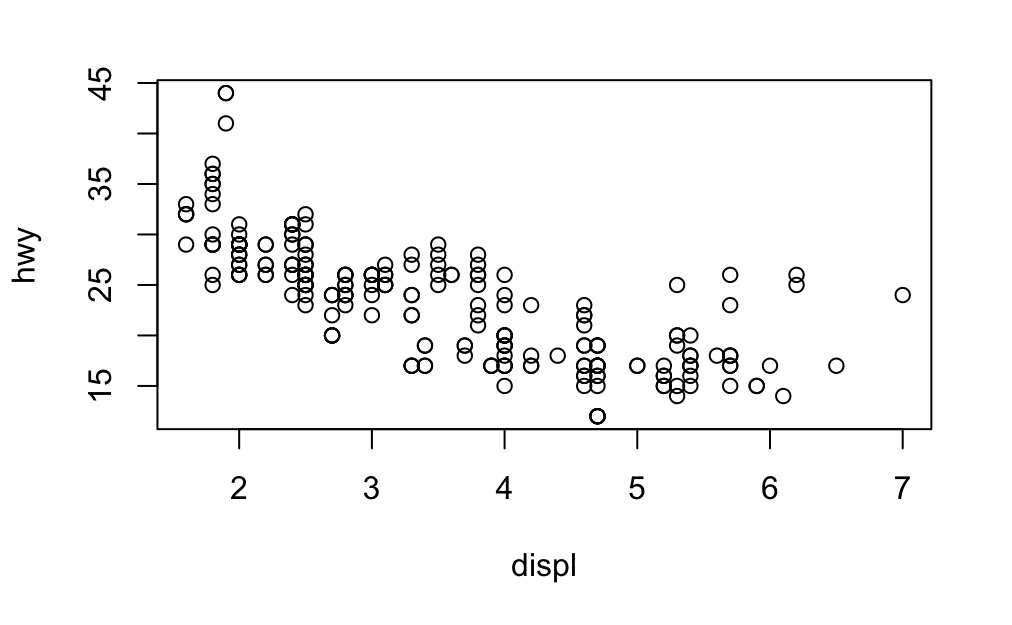

```r
plot(displ, hwy)
```

- an observation is they are the inverse of each other. The plot allows us the more easily pick out the patterns such as the more displacement of the engine the worse miles per gallon the car tends to get. ### Creating and customizing beautiful plots will be using `ggplot()`
- allows more control and a nicer view of the plots

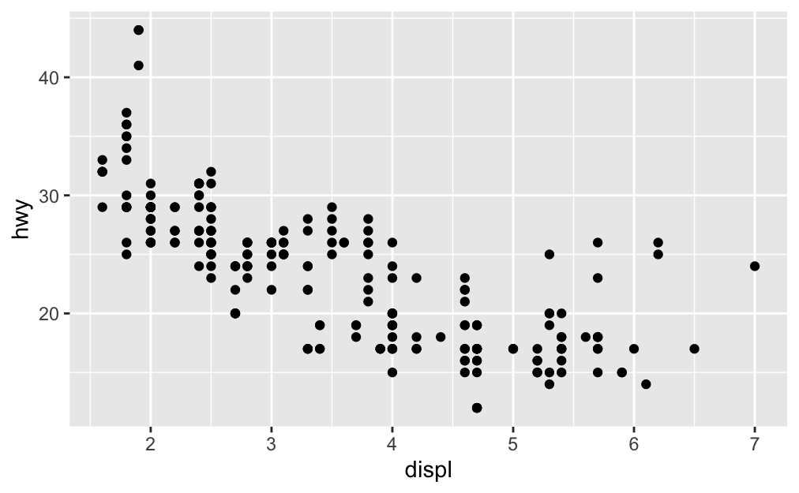

```r
ggplot(data = mpg) + geom_point(mapping=aes(x=displ, y=hwy))
```

### Breaking down `ggplot()`

from the `mpg` data, we again examine the relationship between highway miles per gallon as a function of engine displacement: `ggplot(data = mpg) + geom_point(mapping=aes(x=displ, y=hwy))` the `ggplot()` function creates a coordinate system that we can add layers to, and we have told it to use `mpg` to make subsequent layers. we can add scatterplot layer using `geom_point()` function, which takes the `mapping` argument. the `mapping` argument defines how variables are mapped to visual properties.

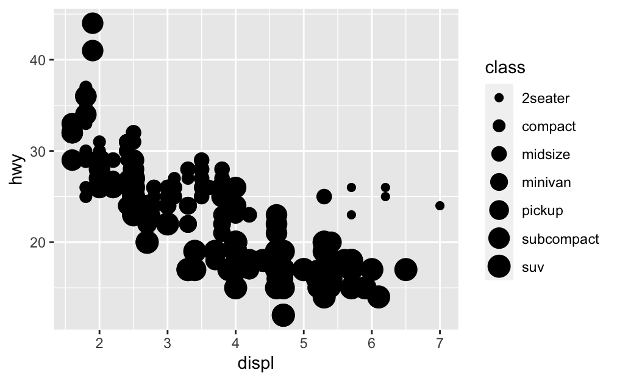

```r
ggplot(data = mpg) + geom_point(mapping=aes(x=displ, y=hwy, size=class))
```

the reasons why are:

1. size implies a quantity of some sort
2. data could be hidden behind some of the larger data points

the next example shows using a grayscale

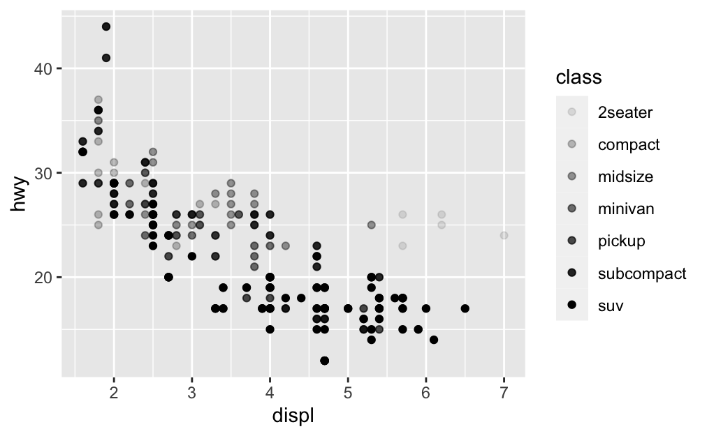

```r
ggplot(data = mpg) + geom_point(mapping=aes(x=displ, y=hwy, alpha=class))
```

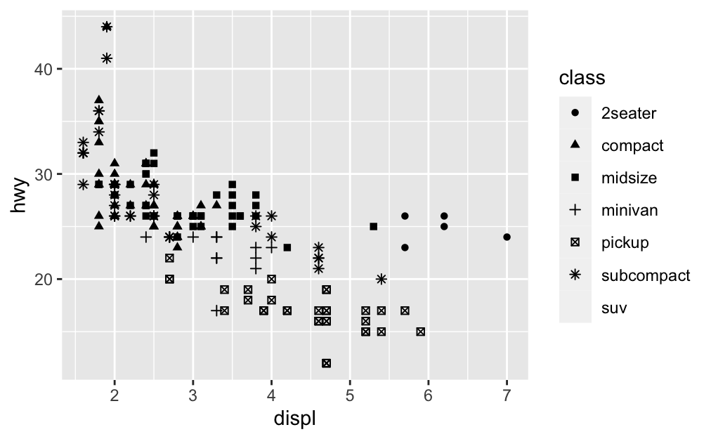

```r
ggplot(data = mpg) + geom_point(mapping=aes(x=displ, y=hwy, shape=class))
```

there are only 6 different shapes, not a good idea for large amounts of different data

lets change the color of the points, must take out of `aes` section because it is not longer an aesthetic. the color blue is set as an argument of the `greom_point()` function, and not the `aes()` function.

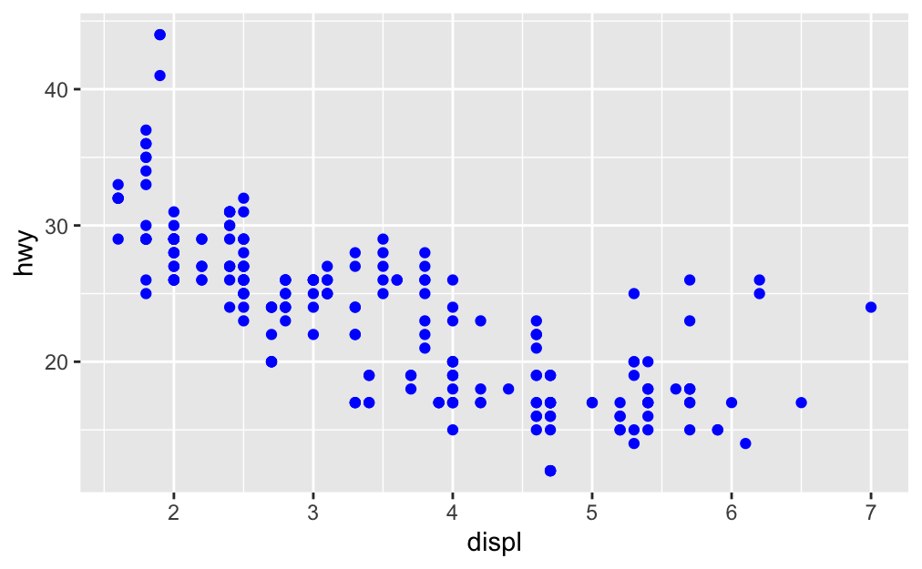

```r
ggplot(data = mpg) + geom_point(mapping=aes(x=displ, y=hwy), color="blue") #the color blue is an argument of `geom_point()`
```

the aesthetic, `aes()`, can be used to set colors of different classes.

### example of complicated manual aesthetic settings

```
Ignoring unknown parameters: aplha
```

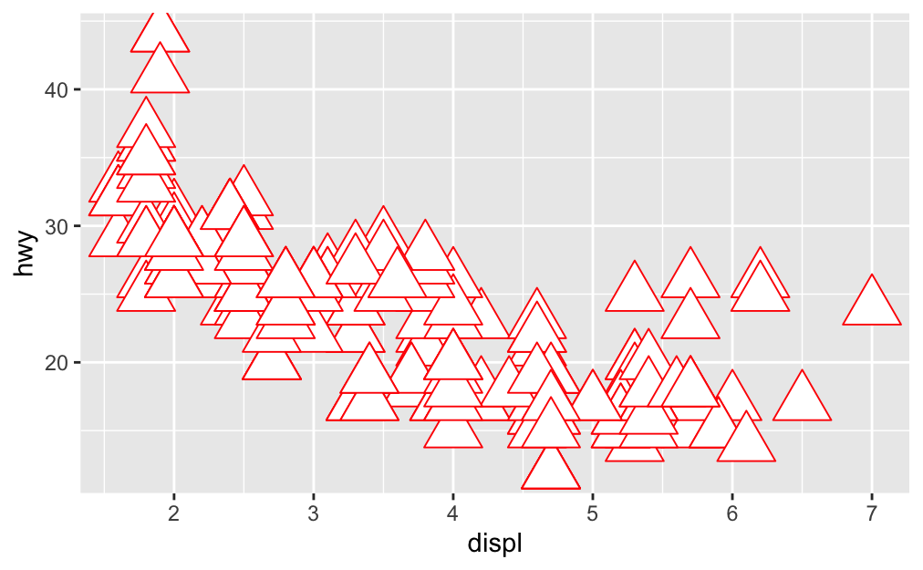

```r
ggplot(data=mpg) + geom_point(mapping=aes(x=displ, y=hwy), shape=24, size=8, aplha=0.5, color='red', fill='white')
```

### example: mapping multiple aesthetics (fuel type and car type)

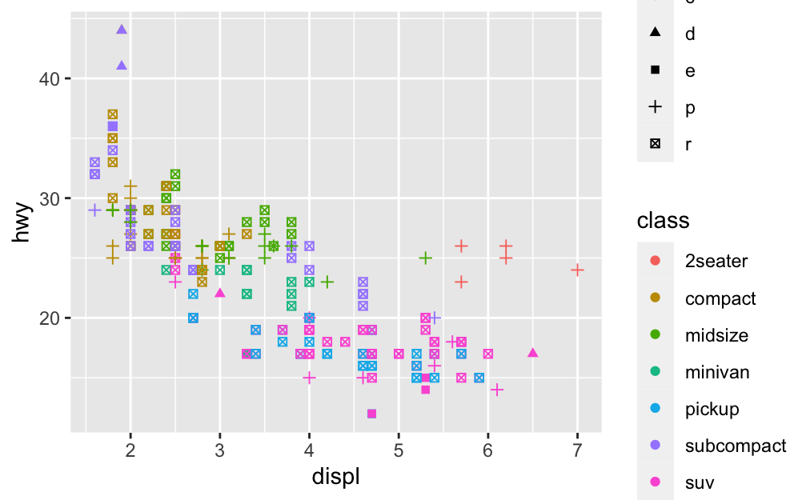

```r
ggplot(data = mpg) + geom_point(mapping = aes(x = displ, y=hwy, color=class, shape=fl))
```

## overlapping points in plots

*overplotting* occurs because values of `displ` are rounded to one decimal place and values of `hwy` are rounded to the nearest integer. ## using `jitter` to deal with overlapping points

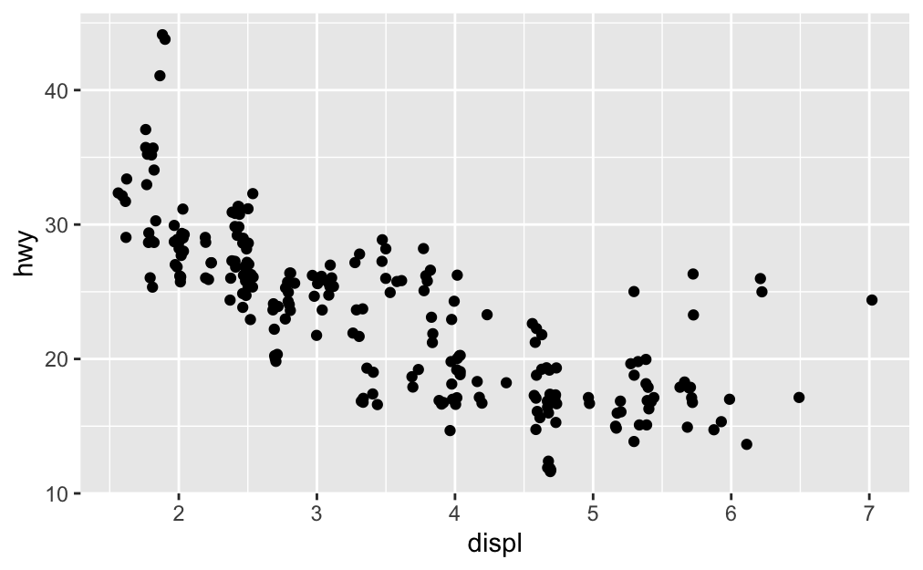

```r
ggplot(data = mpg) + geom_point(mapping = aes(x = displ, y=hwy), position = 'jitter')
```

### Automatic jittering with `geom_jitter()`

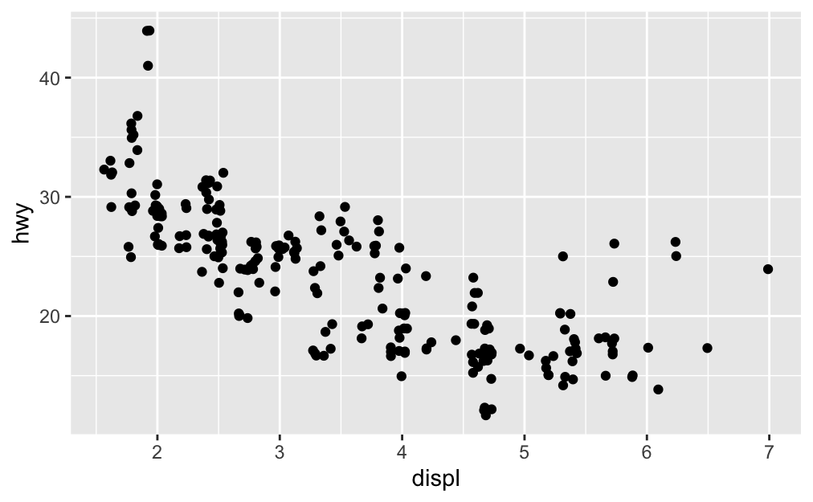

```r
ggplot(data = mpg) + geom_jitter(mapping = aes(x = displ, y=hwy))
```

## Facets

- Aesthetics are useful for visualizing differences among subsets of data.
- Another way to extract such patterns is to use *facets*, which create subplots for different subsets of the data.
- Facets are particularly useful for categorical data, in which each subplot represents a sensible subdivision of the data.
- To facet a pot by a single variable (e.g., car type), we can use the `facet_wrap()` function where the first argument is a formula created using the tilde (~) character.

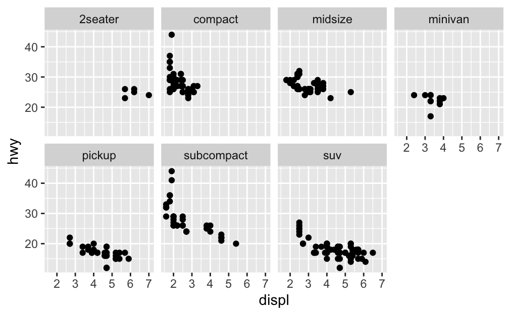

```r
ggplot(data = mpg) + geom_point(mapping = aes(x = displ, y=hwy)) + facet_wrap(~ class, nrow = 2)
```

cases with fewer data points makes it hard to see a trend, so might want to remove them ### Faceting data based on car type across two columns by inceasing the number of columns, can allow us to see the data better

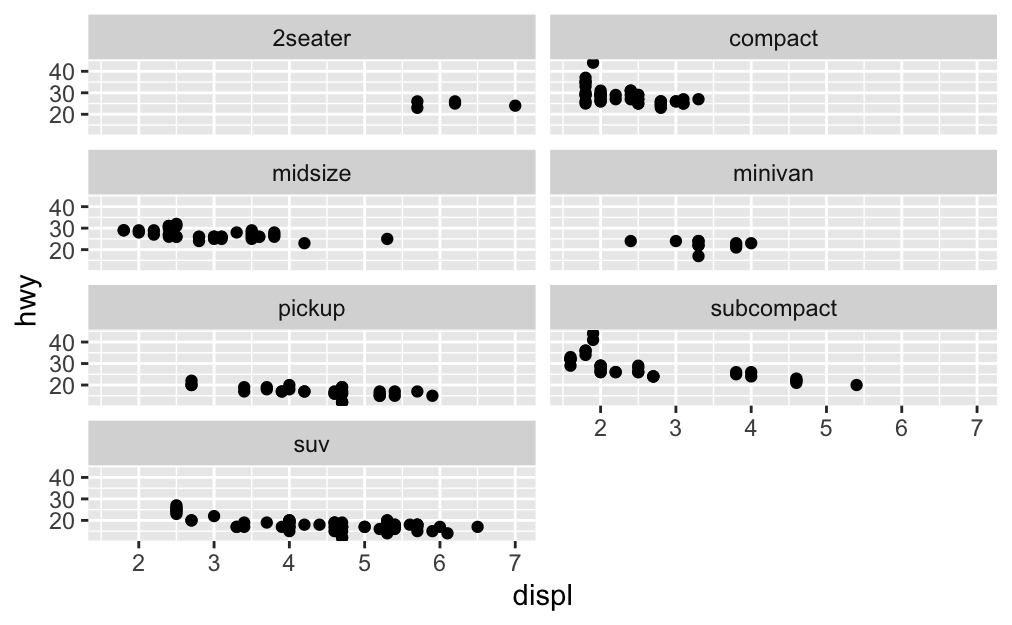

```r
ggplot(data = mpg) + geom_point(mapping = aes(x = displ, y=hwy)) + facet_wrap(~ class, ncol=2)
```

### Faceting data across a combination of two features

- so far we have considered facet_wrap(), which allows us to split data based on a single feature.
- However, it can sometimes be useful to examine two features at once.
- The facet_grid() function allows data to be plotted in subplots, with one feature representing subplot rows and another feature representing subplot columns.
- The first argument of facet_grid() is a *formula of the form*: `row_feature ~ column_feature`

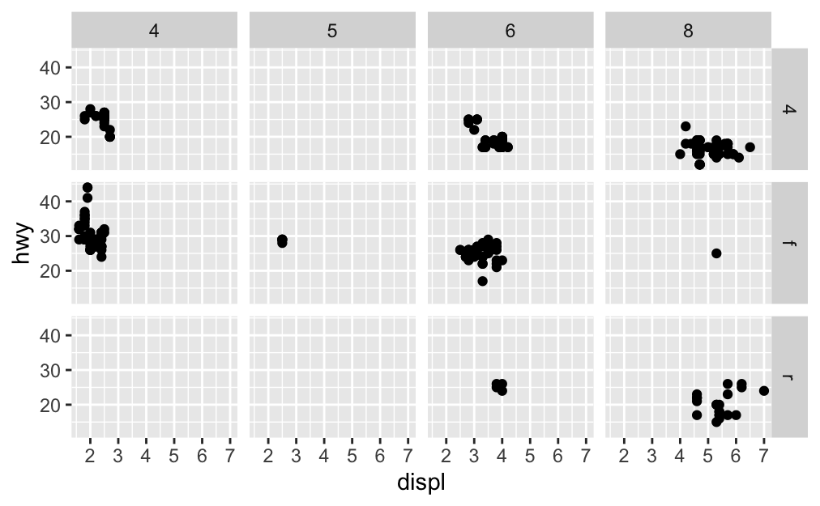

```r
ggplot(data = mpg) +
geom_point(mapping = aes(x = displ, y = hwy)) + facet_grid(drv ~ cyl)
```

### Different types of geoms use by plotting type

| Graph type | Geom Type |
| --- | --- |
| bar | `bar` |
| line | `line` |
| boxplot | `boxplot` |
| … | … |
| scatter | `point` |

- Scatterplots break the pattern, such that their geometric object is not “scatter”, but instead “point”. We have already made scatterplots with the function geom_point(). ### Plotting a smoothed line fitted with a confidence interval
- will show the 95% confidence interval around the smooth line

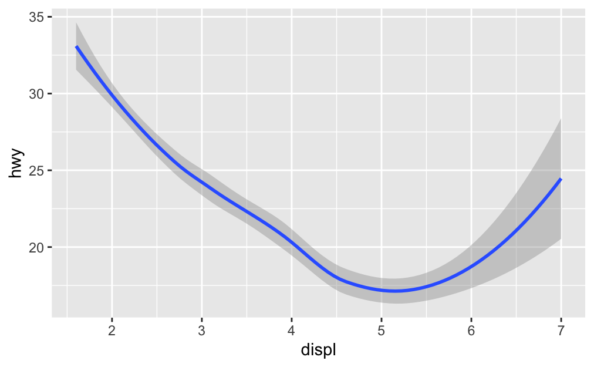

```r
ggplot(data=mpg) + geom_smooth(mapping = aes(x=displ, y=hwy))
```

### What geom_smooth() is plotting

- In the command `geom_smooth(mapping = aes(x = displ, y = hwy))` we told R to plot a smoothed line and to display 95% confidence bands by default around the smoothed line.
- Recall that there is a 95% percent chance that this confidence interval contains the true population mean.
- There are a number of arguments for the geom_smooth() function that permit flexibility, such as changing the type of confidence interval, not including the confidence interval, or even creating separate smoothing lines and confidence intervals for subsets of data. #### Changing the confidence level to 99%

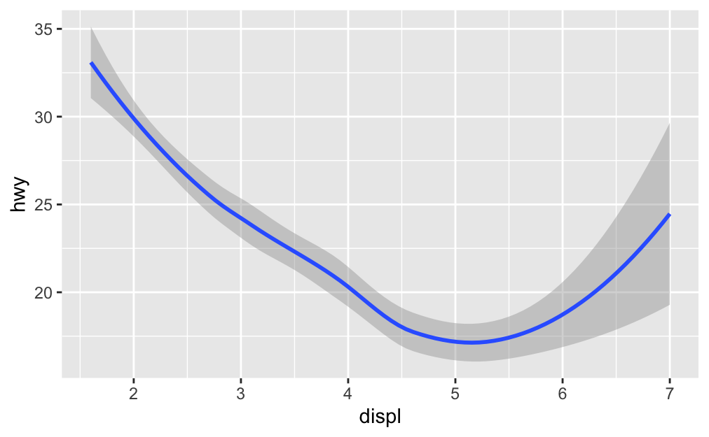

```r
ggplot(data = mpg) + geom_smooth(mapping = aes(x=displ, y=hwy), level = 0.99)
```

#### can also add both `geom_point()` and `geom_smooth()` to same plot

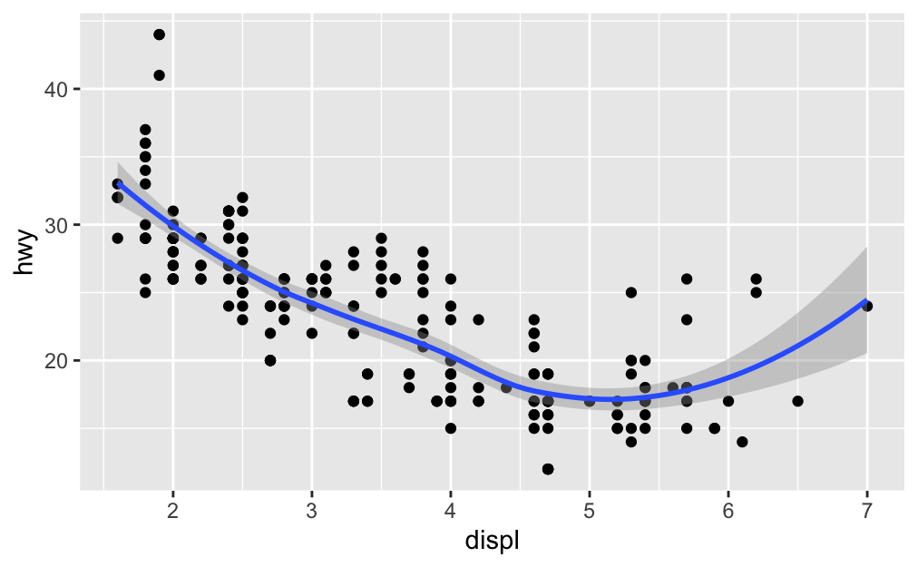

```r
ggplot(data=mpg, mapping = aes(x=displ, y=hwy)) + geom_point() + geom_smooth()
```

### Adding color to scatterplot based on car type

- this will only add color to the point, will not change the color of smooth

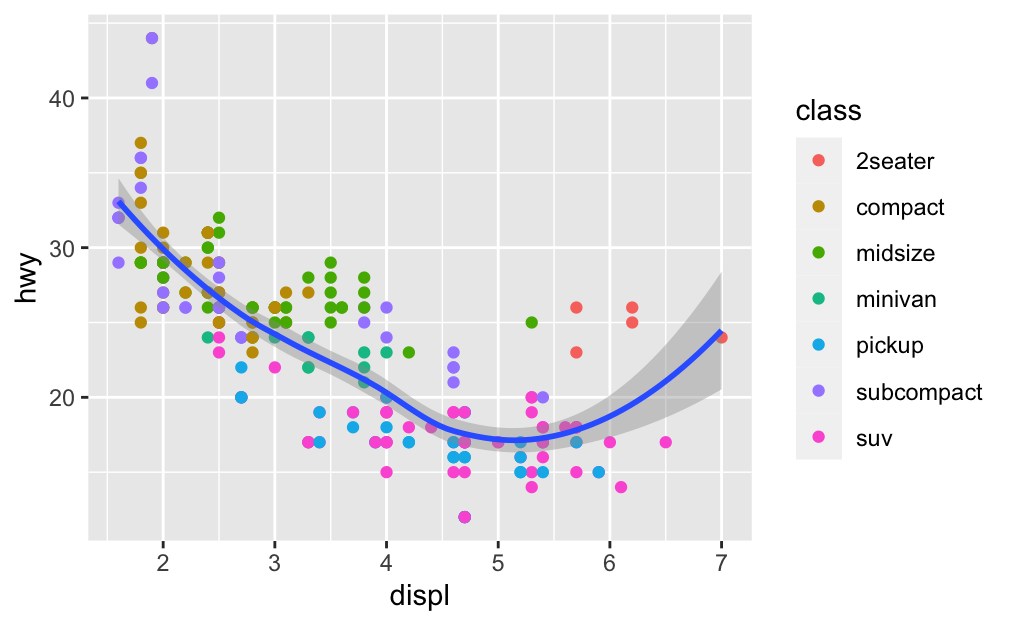

```r
ggplot(data = mpg, mapping = aes(x = displ, y = hwy)) + geom_point(mapping = aes(color = class)) + geom_smooth()
```

### Adding color based on drive in scatter and smoothed plots

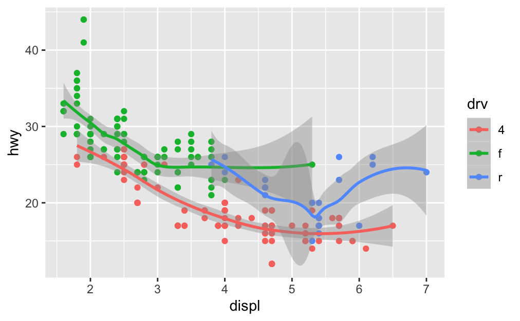

```r
ggplot(data = mpg, mapping = aes(x = displ, y = hwy, color = drv)) +
    geom_point() +
    geom_smooth()
```

## Bar plots

- Bar plots display frequencies of classes of categorical data.
- To explore the use of bar plots, we will examine a new dataset called diamonds, which comes tidied in a data frame in `tidyverse`.
- This data frame has 53,940 rows (observations) with 10 columns (features) containing attributes of `diamonds`.

```r
diamonds
```

| carat | cut | color | clarity | depth | table | price | x | y | z |
| --- | --- | --- | --- | --- | --- | --- | --- | --- | --- |
| 0.23 | Ideal | E | SI2 | 61.5 | 55.0 | 326 | 3.95 | 3.98 | 2.43 |
| 0.21 | Premium | E | SI1 | 59.8 | 61.0 | 326 | 3.89 | 3.84 | 2.31 |
| 0.23 | Good | E | VS1 | 56.9 | 65.0 | 327 | 4.05 | 4.07 | 2.31 |
| 0.29 | Premium | I | VS2 | 62.4 | 58.0 | 334 | 4.20 | 4.23 | 2.63 |
| 0.31 | Good | J | SI2 | 63.3 | 58.0 | 335 | 4.34 | 4.35 | 2.75 |
| 0.24 | Very Good | J | VVS2 | 62.8 | 57.0 | 336 | 3.94 | 3.96 | 2.48 |
| 0.24 | Very Good | I | VVS1 | 62.3 | 57.0 | 336 | 3.95 | 3.98 | 2.47 |
| 0.26 | Very Good | H | SI1 | 61.9 | 55.0 | 337 | 4.07 | 4.11 | 2.53 |
| 0.22 | Fair | E | VS2 | 65.1 | 61.0 | 337 | 3.87 | 3.78 | 2.49 |
| 0.23 | Very Good | H | VS1 | 59.4 | 61.0 | 338 | 4.00 | 4.05 | 2.39 |

[output cut: 990 more lines]

- don’t always know what everything in the data set means, so we can use the `help()` function to display more information on the data

```r
help(diamonds)
```

### Bar plot showing distribution of diamond quality

We can create a bar plot to display diamond quality (cut) on the 𝑥 axis, and the count for a diamond of that quality on the 𝑦 axis:

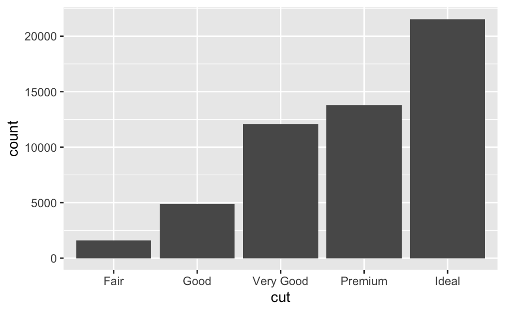

```r
ggplot(data = diamonds) + geom_bar(mapping = aes(x = cut))
```

### Statistical transformation in geom_bar()

- The geom_bar() function first transforms data into counts, which are then returned for each cut.
- That is, five counts are returned, each summarizing how often a cut appears in the dataset.
- These transformed data (counts) are then displayed on the 𝑦 axis as a function of cut on the 𝑥 axis using the geom_bar() function. ## Histograms
- Histograms display distributions for continuous numerical variables. For example, we can create a histogram showing the distribution of highway miles per gallon in the mpg data frame:

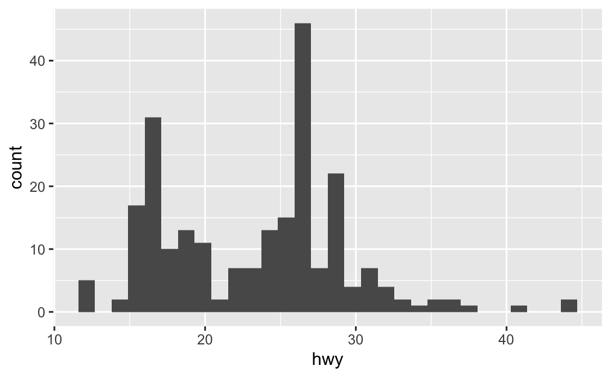

```r
ggplot(data = mpg, mapping = aes(x = hwy)) +
geom_histogram()
```

#### changing the size of the bins

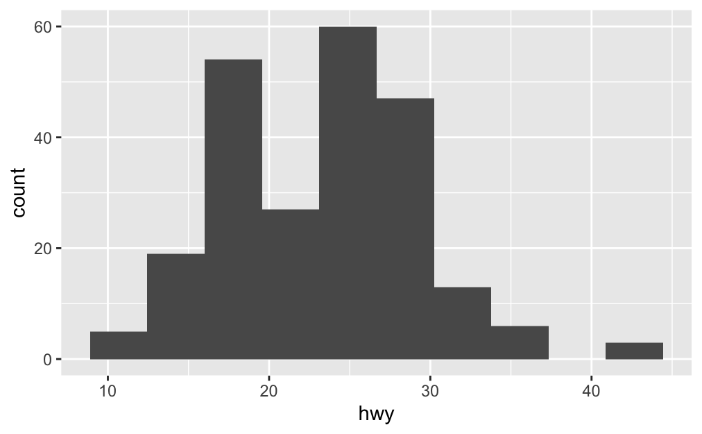

```r
ggplot(data = mpg, mapping = aes(x = hwy)) +
geom_histogram(bins=10)
```

### starts explaining homework 1

### starts going over quickly what we will be doing next week

- ends lecture

# 2-3-21 - Continues Lecture 4

- reviews what she went over last class

## Bar Plots

- Bar plots are nice ways in showing frequencies of classes of categorical data.

```r
library(tidyverse)
diamonds
```

| carat | cut | color | clarity | depth | table | price | x | y | z |
| --- | --- | --- | --- | --- | --- | --- | --- | --- | --- |
| 0.23 | Ideal | E | SI2 | 61.5 | 55.0 | 326 | 3.95 | 3.98 | 2.43 |
| 0.21 | Premium | E | SI1 | 59.8 | 61.0 | 326 | 3.89 | 3.84 | 2.31 |
| 0.23 | Good | E | VS1 | 56.9 | 65.0 | 327 | 4.05 | 4.07 | 2.31 |
| 0.29 | Premium | I | VS2 | 62.4 | 58.0 | 334 | 4.20 | 4.23 | 2.63 |
| 0.31 | Good | J | SI2 | 63.3 | 58.0 | 335 | 4.34 | 4.35 | 2.75 |
| 0.24 | Very Good | J | VVS2 | 62.8 | 57.0 | 336 | 3.94 | 3.96 | 2.48 |
| 0.24 | Very Good | I | VVS1 | 62.3 | 57.0 | 336 | 3.95 | 3.98 | 2.47 |
| 0.26 | Very Good | H | SI1 | 61.9 | 55.0 | 337 | 4.07 | 4.11 | 2.53 |
| 0.22 | Fair | E | VS2 | 65.1 | 61.0 | 337 | 3.87 | 3.78 | 2.49 |
| 0.23 | Very Good | H | VS1 | 59.4 | 61.0 | 338 | 4.00 | 4.05 | 2.39 |

[output cut: 990 more lines]

```r
help(diamonds)
```

### Bar plot showing distribution of diamond quality

- We can create a bar plot to display diamond quality (cut) on the 𝑥 axis, and the count for a diamond of that quality on the 𝑦 axis:

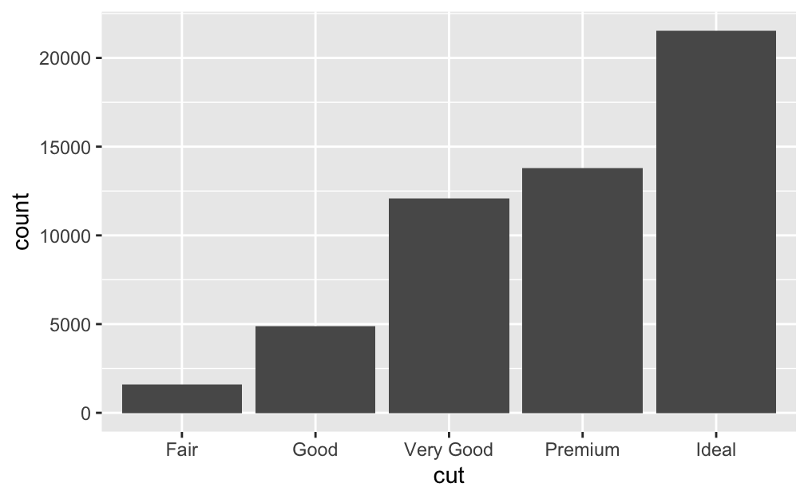

```r
ggplot(data = diamonds) + geom_bar(mapping = aes(x = cut))
```

### Statistical transformation in geom_bar()

- The geom_bar() function first transforms data into counts, which are then returned for each cut.
- That is, five counts are returned, each summarizing how often a cut appears in the dataset.
- These transformed data (counts) are then displayed on the 𝑦 axis as a function of cut on the 𝑥 axis using the geom_bar() function. ### Histograms
- Histograms display distributions for continuous numerical variables. - For example, we can create a histogram showing the distribution of highway miles per gallon in the mpg data frame:

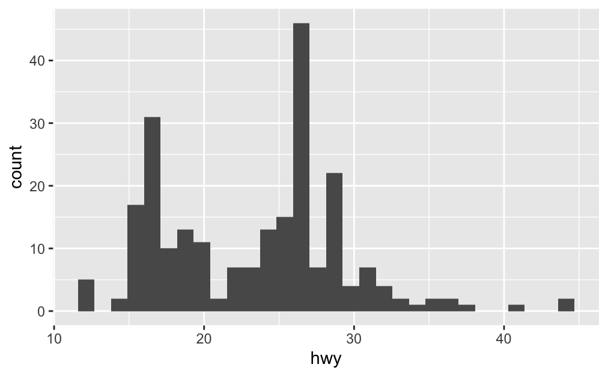

```r
ggplot(data = mpg, mapping = aes(x = hwy)) +
geom_histogram()
```

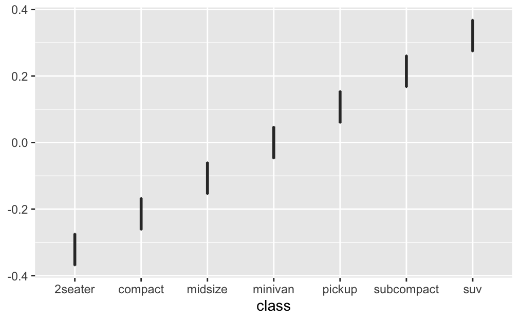

```r
ggplot(data = mpg, mapping = aes(x=class, h=hwy)) + geom_boxplot()
```

## Plotting objects can be assigned to a variable

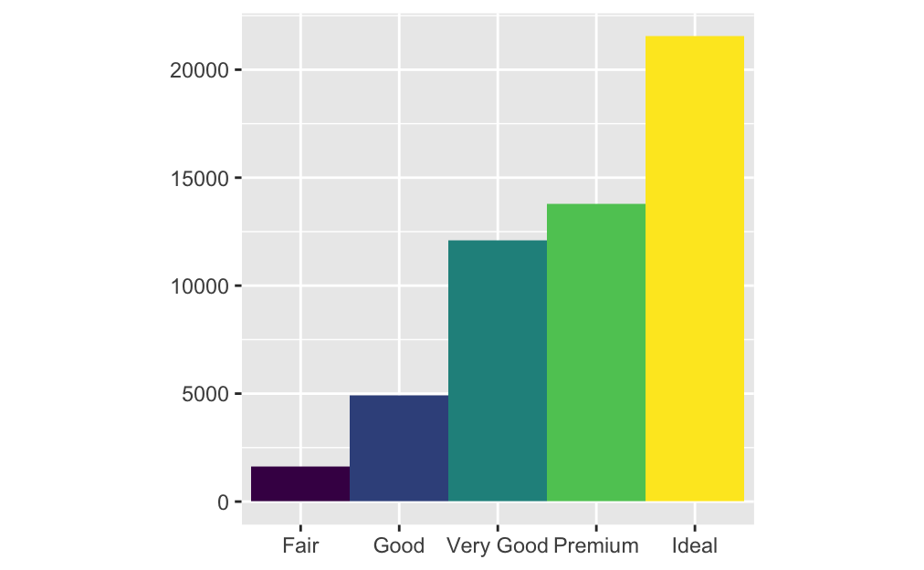

```r
bar = ggplot(data = diamonds) + geom_bar(mapping = aes(x=cut, fill=cut), show.legend = FALSE, width = 1) + theme(aspect.ratio = 1) + labs(x=NULL, y=NULL)
bar
```

### flipping the corrdinates by adding that layer

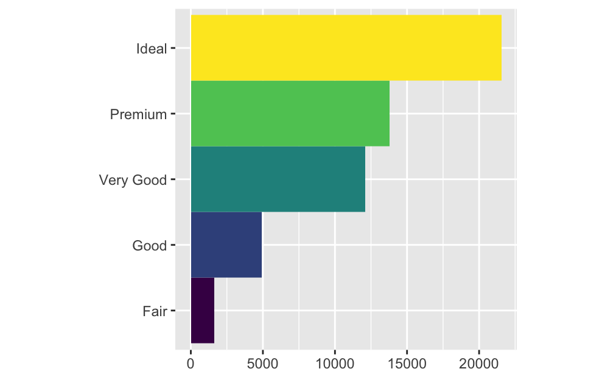

```r
bar + coord_flip()
```

### Coxcomb Chart

- **Coxcomb Chart** is similar to pie chart
- may not be the best way to present this information

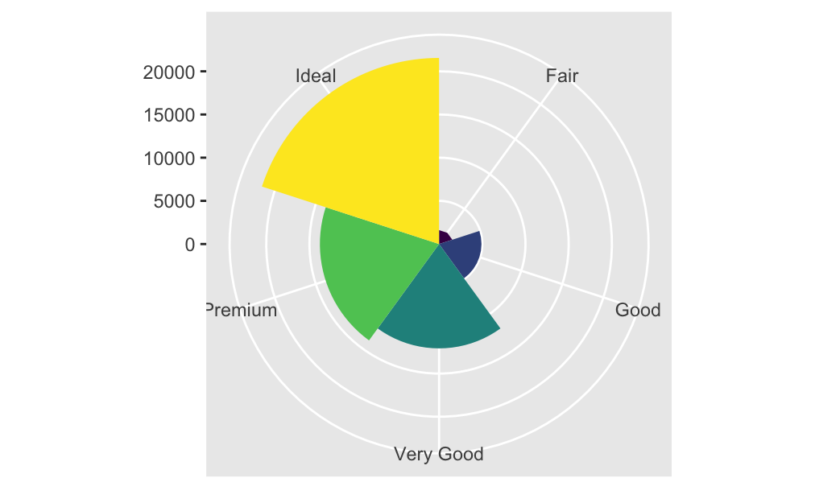

```r
bar + coord_polar()
```

- can change the theme of the graph

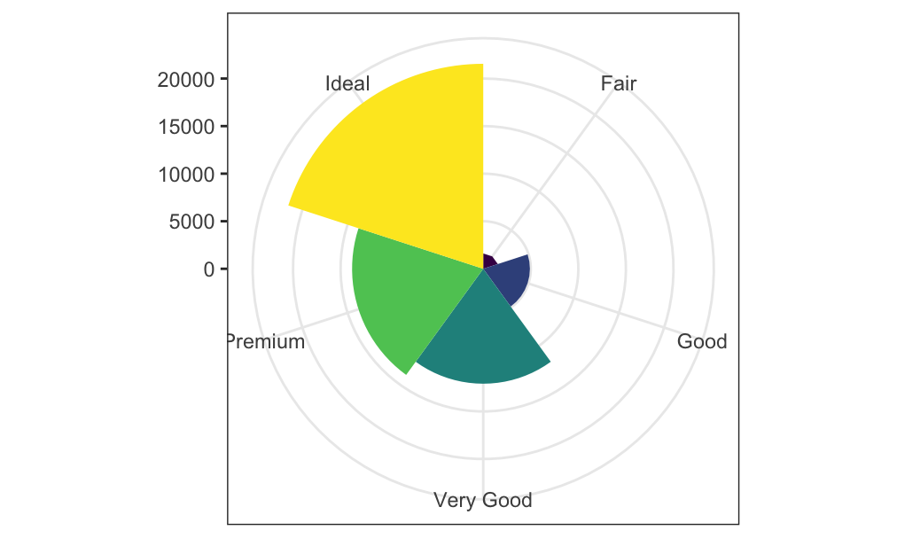

```r
bar + coord_polar() + theme_bw()
```

## Goes over `ggplot()` cheat sheet

## lecture summary

- discussed the first few steps of data science in R
- next will begin about how to design *models* so that we can learn and make preditction from data.
- *linear regression*, a type of supervised learning in which we fit a linear model to data so that we can make predictions about a response variable from one or more features.